# 7. Sintetização

# 1 Diretório

# 2 Pacotes e dados

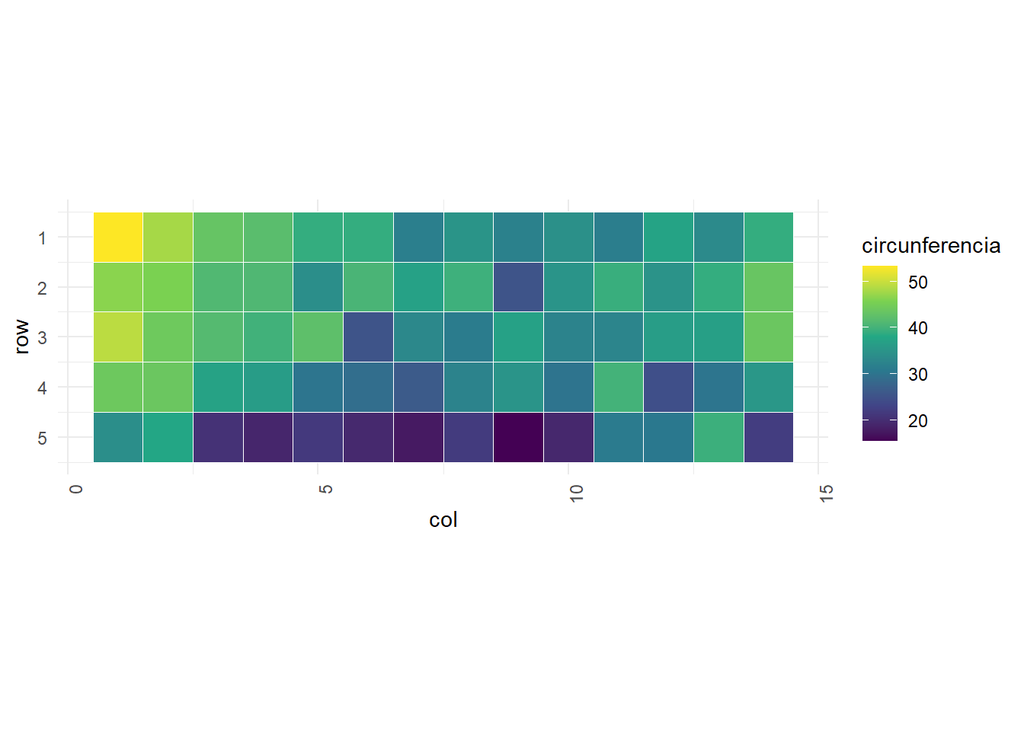

```r
library(rio)
library(tidyverse)
library(metan)

# set_wd_here("data")
# dados
df <- import("eucalipto.xlsx")
df_retangulo <-
  df |>
  mutate(col = rep(1:14, 5),
         row = rep(1:5, each = 14))

p1 <-
  ggplot(df_retangulo, aes(x = col, y = row, z = circunferencia)) +
  geom_tile(aes(fill = circunferencia), color = "white") +
  scale_fill_viridis_c() +
  theme_minimal() +
  scale_y_reverse() +
  theme(axis.text.x = element_text(angle = 90, hjust = 1)) +
  coord_fixed(ratio = 1)
p1
```

# 3 Sintetização

Após a organização e mutação dos dados, o cientista precisa resumi-los utilizando alguma métrica de interesse. A média, a mediana, a variância, a frequência, a proporção, por exemplo, são tipos de sumarização que trazem diferentes informações sobre uma variável. No R, a função [`summarise()`](https://dplyr.tidyverse.org/reference/summarise.html) cria um novo data frame. Ele terá uma (ou mais) linhas para cada combinação de variáveis de agrupamento; se não houver variáveis de agrupamento, a saída terá uma única linha resumindo todas as observações na entrada. Ele conterá uma coluna para cada variável de agrupamento e uma coluna para cada uma das estatísticas de resumo que você especificou.

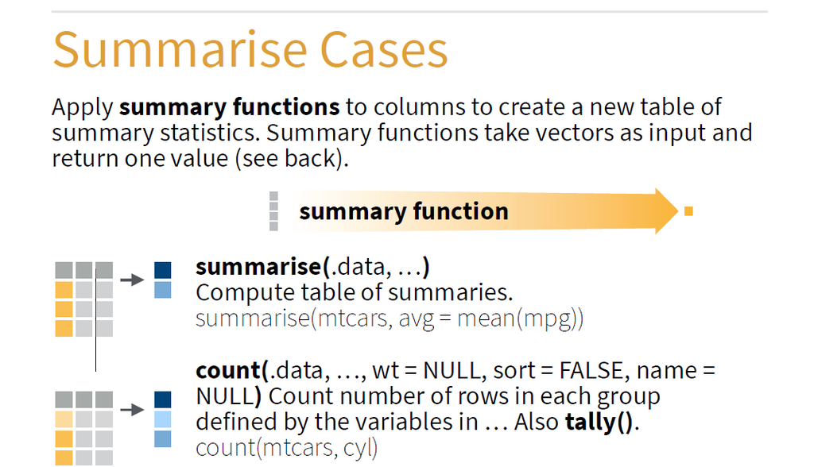

Fonte: https://dplyr.tidyverse.org/index.html